# WUM - PD2

## Praca Domowa 2

W rozpoczęciu pracy domowej zacznę od zainstalowania użytych weń pakietów oraz wczytanie ramki danych. Jednakże, by nie "zanieczyszczać" raportu wspomnę, iż dokonałem wcześniejszej instalacji pakietów z użyciem "!pip install category_encoders".

```python
import category_encoders as ce
import numpy as np
import seaborn as sns
import pandas as pd
import matplotlib.pyplot as plt
from sklearn.preprocessing import OneHotEncoder
import warnings
warnings.filterwarnings('ignore')
```

```python
df = pd.read_csv('allegro-api-transactions.csv')
```

Zacznijmy od wstępnego spojrzenia na naszą ramkę danych:

```python
df
```

|  | lp | date | item_id | categories | pay_option_on_delivery | pay_option_transfer | seller | price | it_is_allegro_standard | it_quantity | it_is_brand_zone | it_seller_rating | it_location | main_category |
| --- | --- | --- | --- | --- | --- | --- | --- | --- | --- | --- | --- | --- | --- | --- |
| 0 | 0 | 2016-04-03 21:21:08 | 4753602474 | ['Komputery', 'Dyski i napędy', 'Nośniki', 'No... | 1 | 1 | radzioch666 | 59.99 | 1 | 997 | 0 | 50177 | Warszawa | Komputery |
| 1 | 1 | 2016-04-03 15:35:26 | 4773181874 | ['Odzież, Obuwie, Dodatki', 'Bielizna damska',... | 1 | 1 | InwestycjeNET | 4.90 | 1 | 9288 | 0 | 12428 | Warszawa | Odzież, Obuwie, Dodatki |
| 2 | 2 | 2016-04-03 14:14:31 | 4781627074 | ['Dom i Ogród', 'Budownictwo i Akcesoria', 'Śc... | 1 | 1 | otostyl_com | 109.90 | 1 | 895 | 0 | 7389 | Leszno | Dom i Ogród |
| 3 | 3 | 2016-04-03 19:55:44 | 4783971474 | ['Książki i Komiksy', 'Poradniki i albumy', 'Z... | 1 | 1 | Matfel1 | 18.50 | 0 | 971 | 0 | 15006 | Wola Krzysztoporska | Książki i Komiksy |
| 4 | 4 | 2016-04-03 18:05:54 | 4787908274 | ['Odzież, Obuwie, Dodatki', 'Ślub i wesele', '... | 1 | 1 | PPHU_RICO | 19.90 | 1 | 950 | 0 | 32975 | BIAŁYSTOK | Odzież, Obuwie, Dodatki |
| ... | ... | ... | ... | ... | ... | ... | ... | ... | ... | ... | ... | ... | ... | ... |
| 420015 | 420015 | 2016-04-03 20:27:13 | 6099625607 | ['RTV i AGD', 'Sprzęt audio dla domu', 'Odtwar... | 0 | 0 | iwona7012 | 180.00 | 0 | 0 | 0 | 176 | Kraśnik | RTV i AGD |
| 420016 | 420016 | 2016-04-03 22:35:02 | 6099634607 | ['Uroda', 'Makijaż', 'Oczy', 'Tusze do rzęs'] | 1 | 1 | Dolce_Cosmetics | 14.99 | 1 | 2 | 0 | 34851 | Dzierżoniów | Uroda |
| 420017 | 420017 | 2016-04-03 22:38:57 | 6099780407 | ['Odzież, Obuwie, Dodatki', 'Przebrania, kosti... | 1 | 1 | pewex4all | 5.99 | 1 | 470 | 0 | 983 | Supraśl | Odzież, Obuwie, Dodatki |
| 420018 | 420018 | 2016-04-03 22:44:17 | 6099801007 | ['Dla Dzieci', 'Rowery i pojazdy', 'Rowery bie... | 1 | 0 | kostasia | 200.00 | 0 | 0 | 0 | 163 | Poznań | Dla Dzieci |
| 420019 | 420019 | 2016-04-03 23:08:23 | 6099873207 | ['Motoryzacja', 'Części samochodowe', 'Koła, f... | 0 | 0 | Malami172 | 500.00 | 0 | 0 | 0 | 265 | Pszów | Motoryzacja |

420020 rows × 14 columns

```python
df.info()
```

```
<class 'pandas.core.frame.DataFrame'>
RangeIndex: 420020 entries, 0 to 420019
Data columns (total 14 columns):
 #   Column                  Non-Null Count   Dtype
---  ------                  --------------   -----
 0   lp                      420020 non-null  int64
 1   date                    420020 non-null  object
 2   item_id                 420020 non-null  int64
 3   categories              420020 non-null  object
 4   pay_option_on_delivery  420020 non-null  int64
 5   pay_option_transfer     420020 non-null  int64
 6   seller                  420020 non-null  object
 7   price                   420020 non-null  float64
 8   it_is_allegro_standard  420020 non-null  int64
 9   it_quantity             420020 non-null  int64
 10  it_is_brand_zone        420020 non-null  int64
 11  it_seller_rating        420020 non-null  int64
 12  it_location             420020 non-null  object
 13  main_category           420020 non-null  object
dtypes: float64(1), int64(8), object(5)
memory usage: 44.9+ MB
```

Jak widzimy nie będziemy mieli problemów z wartościami null oraz utratą danych.

## Kodowanie zmiennych kategorycznych

Zacznijmy od zajęcia się pierwszym zadaniem, mianowicie z poleceniem wykonania target_encoding dla kolumny it_location

```python
#Sprawdźmy ilość unikalnych wartości w tabeli it_location
print(df['it_location'].unique())
len(df['it_location'].unique())
```

```
['Warszawa' 'Leszno' 'Wola Krzysztoporska' ... 'Tarnawa-Góra' 'Zbytów'
 'Dąbrowa k/Poznania']
```

```
10056
```

```python
Target_encoder = ce.TargetEncoder()
encoded = Target_encoder.fit_transform(df['it_location'],df['price'])
df = df.drop(['it_location'],axis = 1)
df.insert(10,'it_encoded',encoded,True)
df
```

|  | lp | date | item_id | categories | pay_option_on_delivery | pay_option_transfer | seller | price | it_is_allegro_standard | it_quantity | it_encoded | it_is_brand_zone | it_seller_rating | main_category |
| --- | --- | --- | --- | --- | --- | --- | --- | --- | --- | --- | --- | --- | --- | --- |
| 0 | 0 | 2016-04-03 21:21:08 | 4753602474 | ['Komputery', 'Dyski i napędy', 'Nośniki', 'No... | 1 | 1 | radzioch666 | 59.99 | 1 | 997 | 85.423398 | 0 | 50177 | Komputery |
| 1 | 1 | 2016-04-03 15:35:26 | 4773181874 | ['Odzież, Obuwie, Dodatki', 'Bielizna damska',... | 1 | 1 | InwestycjeNET | 4.90 | 1 | 9288 | 85.423398 | 0 | 12428 | Odzież, Obuwie, Dodatki |
| 2 | 2 | 2016-04-03 14:14:31 | 4781627074 | ['Dom i Ogród', 'Budownictwo i Akcesoria', 'Śc... | 1 | 1 | otostyl_com | 109.90 | 1 | 895 | 61.990914 | 0 | 7389 | Dom i Ogród |
| 3 | 3 | 2016-04-03 19:55:44 | 4783971474 | ['Książki i Komiksy', 'Poradniki i albumy', 'Z... | 1 | 1 | Matfel1 | 18.50 | 0 | 971 | 35.433365 | 0 | 15006 | Książki i Komiksy |
| 4 | 4 | 2016-04-03 18:05:54 | 4787908274 | ['Odzież, Obuwie, Dodatki', 'Ślub i wesele', '... | 1 | 1 | PPHU_RICO | 19.90 | 1 | 950 | 117.191956 | 0 | 32975 | Odzież, Obuwie, Dodatki |
| ... | ... | ... | ... | ... | ... | ... | ... | ... | ... | ... | ... | ... | ... | ... |
| 420015 | 420015 | 2016-04-03 20:27:13 | 6099625607 | ['RTV i AGD', 'Sprzęt audio dla domu', 'Odtwar... | 0 | 0 | iwona7012 | 180.00 | 0 | 0 | 24.306929 | 0 | 176 | RTV i AGD |
| 420016 | 420016 | 2016-04-03 22:35:02 | 6099634607 | ['Uroda', 'Makijaż', 'Oczy', 'Tusze do rzęs'] | 1 | 1 | Dolce_Cosmetics | 14.99 | 1 | 2 | 66.785334 | 0 | 34851 | Uroda |
| 420017 | 420017 | 2016-04-03 22:38:57 | 6099780407 | ['Odzież, Obuwie, Dodatki', 'Przebrania, kosti... | 1 | 1 | pewex4all | 5.99 | 1 | 470 | 18.682800 | 0 | 983 | Odzież, Obuwie, Dodatki |
| 420018 | 420018 | 2016-04-03 22:44:17 | 6099801007 | ['Dla Dzieci', 'Rowery i pojazdy', 'Rowery bie... | 1 | 0 | kostasia | 200.00 | 0 | 0 | 106.203076 | 0 | 163 | Dla Dzieci |
| 420019 | 420019 | 2016-04-03 23:08:23 | 6099873207 | ['Motoryzacja', 'Części samochodowe', 'Koła, f... | 0 | 0 | Malami172 | 500.00 | 0 | 0 | 78.136792 | 0 | 265 | Motoryzacja |

420020 rows × 14 columns

Jeżeli chodzi o przypadek one-hot-encoding, to nie będę nawet podejmywał próby jego wykonania dla powyższej ramki. Jak wcześniej pokazałem, dla kolumny it_location, istnieje 10056 unikalnych wartości, co po transformacji przy użyciu one-hot, powiększyłoby naszą ramkę danych kilkuset krotnie. Widać od razu, iż rozwiązanie to byłoby wysoce nieefektywne, zatem w kwestii one-hot pozostawię tylko ten komentarz.

### Zobaczmy jak prezentują się dane po wykonaniu target encoding

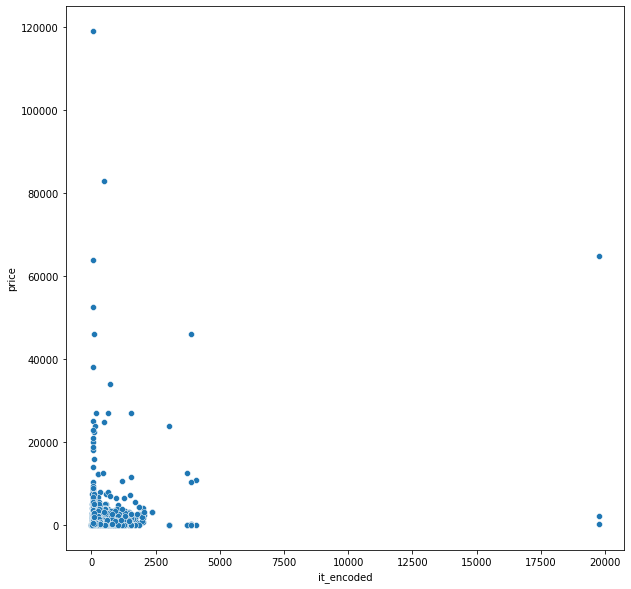

```python
plt.figure(figsize=(10,10))
sns.scatterplot(x=df['it_encoded'],y=df['price'])
plt.show()
```

Usuńmy outliery by otrzymać bardziej przejrzyste spojrzenie na ramkę. Zastosuję metodę pozbycia się skrajnych percentyli z naszej ramki.

```python
df_plot = df
upper_limit_it = df_plot['it_encoded'].quantile(0.95)
lower_limit_it = df_plot['it_encoded'].quantile(0.05)
upper_limit_price = df_plot['price'].quantile(0.95)
lower_limit_price = df_plot['price'].quantile(0.05)
df_plot = df[(df['it_encoded'] < upper_limit_it) & (df['it_encoded']>lower_limit_it)&(df['price']<upper_limit_price)&(df['price']>lower_limit_price)]
```

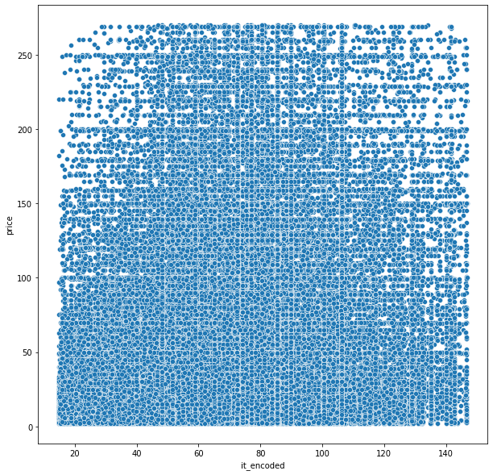

```python
plt.figure(figsize=(10,10))
sns.scatterplot(x=df_plot['it_encoded'],y=df_plot['price'])
plt.show()
```

Jak widzimy, taka dystrybucja jest o wiele bardziej pokazuje nam całkowitą jednostajność danych.

## Porównanie one-hot oraz targer encoding

a. One-hot

1. One hot encoding sprawdza się dla umiarkowanej liczby danych
2. Jest wygodny dla zadań klasyfikacji
3. Nie ukrywa, zmienia wartości wyjściowej danych, więc nie będzie potrzebna zamiana zmiennych
4. Po przekroweczniu pewnej ilości unikalnych zmiennych, analiza staje się długa, a tabela zajmuje dużą ilość pamięci

b. Target encoding

1. Jest prosty w użyciu oraz nie powoduje dużo problemów z ramką danych
2. Jest idealny również dla dużej ilości danych, nie powiększy nam znacznie objętości danych
3. Tracimy informacje początkowe o danej zmiennej
4. Dla małej ilości danych, może w szczególności 'ukryć' pewne corelacje

## Enkodowanie na 3 sposoby

Teraz przejdźmy do następnego zadania i dokonajmy encodingu "main_cathegory" używając trzech równych encodingów.

Pierw zacznijmy z one-hot encoding.

```python
one_hot_encoder = ce.OneHotEncoder(cols=["main_category"])
df_encoded = one_hot_encoder.fit_transform(df)
df_encoded.iloc[:,13:]
```

|  | main_category_1 | main_category_2 | main_category_3 | main_category_4 | main_category_5 | main_category_6 | main_category_7 | main_category_8 | main_category_9 | main_category_10 | ... | main_category_18 | main_category_19 | main_category_20 | main_category_21 | main_category_22 | main_category_23 | main_category_24 | main_category_25 | main_category_26 | main_category_27 |
| --- | --- | --- | --- | --- | --- | --- | --- | --- | --- | --- | --- | --- | --- | --- | --- | --- | --- | --- | --- | --- | --- |
| 0 | 1 | 0 | 0 | 0 | 0 | 0 | 0 | 0 | 0 | 0 | ... | 0 | 0 | 0 | 0 | 0 | 0 | 0 | 0 | 0 | 0 |
| 1 | 0 | 1 | 0 | 0 | 0 | 0 | 0 | 0 | 0 | 0 | ... | 0 | 0 | 0 | 0 | 0 | 0 | 0 | 0 | 0 | 0 |
| 2 | 0 | 0 | 1 | 0 | 0 | 0 | 0 | 0 | 0 | 0 | ... | 0 | 0 | 0 | 0 | 0 | 0 | 0 | 0 | 0 | 0 |
| 3 | 0 | 0 | 0 | 1 | 0 | 0 | 0 | 0 | 0 | 0 | ... | 0 | 0 | 0 | 0 | 0 | 0 | 0 | 0 | 0 | 0 |
| 4 | 0 | 1 | 0 | 0 | 0 | 0 | 0 | 0 | 0 | 0 | ... | 0 | 0 | 0 | 0 | 0 | 0 | 0 | 0 | 0 | 0 |
| ... | ... | ... | ... | ... | ... | ... | ... | ... | ... | ... | ... | ... | ... | ... | ... | ... | ... | ... | ... | ... | ... |
| 420015 | 0 | 0 | 0 | 0 | 0 | 1 | 0 | 0 | 0 | 0 | ... | 0 | 0 | 0 | 0 | 0 | 0 | 0 | 0 | 0 | 0 |
| 420016 | 0 | 0 | 0 | 0 | 0 | 0 | 0 | 0 | 1 | 0 | ... | 0 | 0 | 0 | 0 | 0 | 0 | 0 | 0 | 0 | 0 |
| 420017 | 0 | 1 | 0 | 0 | 0 | 0 | 0 | 0 | 0 | 0 | ... | 0 | 0 | 0 | 0 | 0 | 0 | 0 | 0 | 0 | 0 |
| 420018 | 0 | 0 | 0 | 0 | 0 | 0 | 0 | 1 | 0 | 0 | ... | 0 | 0 | 0 | 0 | 0 | 0 | 0 | 0 | 0 | 0 |
| 420019 | 0 | 0 | 0 | 0 | 0 | 0 | 1 | 0 | 0 | 0 | ... | 0 | 0 | 0 | 0 | 0 | 0 | 0 | 0 | 0 | 0 |

420020 rows × 27 columns

Jak widzimy kodowanie przebiegło pomyślnie, wytworzone zostało 27 dodatkowych kolumn, kodujących wszystkie unikalne wartości z kolumny main_category. Sprawdźmy czy rzeczywiście kolumna main_category zawiera 27 unikalnychw wartości.

```python
#Zgadza się
len(df['main_category'].unique())
```

```
27
```

#### Jako drugą metodę kodowania zmiennych użyłem CountEncoder.

```python
encoder = ce.CountEncoder(cols=['main_category'])
encoder.fit(df)
df_3 = encoder.transform(df)
df_3.iloc[:,13:]
```

|  | main_category |
| --- | --- |
| 0 | 14491 |
| 1 | 54257 |
| 2 | 91042 |
| 3 | 11572 |
| 4 | 54257 |
| ... | ... |
| 420015 | 20341 |
| 420016 | 28096 |
| 420017 | 54257 |
| 420018 | 42107 |
| 420019 | 45941 |

420020 rows × 1 columns

Ten typ kodowania zmiennych kategorycznych dla każdej z kategorii przyporządkowuje ilość wystąpień danej kategorii. Przy tej metodzie od razu narzuca się fakt, iż istnieje możliwość wystąpienia powtórzen w encodingu.

Sprawdźmy czy stało się tak w naszym przypadku

```python
len(df_3['main_category'].unique())
```

```
27
```

Jak widzimy takie wydarzenie nie zaistniało dla naszej tabeli. Im więcej danych w tabeli, i im mniej oryginalnie unikalnych wartości dla danej zmiennej, tym prawdopowobieństwo takiego zdarzenia jest mniejsze, więc śmiało można stwierdzić, iż count encoding jest przeznaczony dla "sporych" ramek danych.

#### Ostatecznie użyjmy HelmertEncoding

```python
encoder = ce.HelmertEncoder(cols=['main_category'])
encoder.fit(df)
df_4 = encoder.transform(df)
df_4.iloc[:,13:]
```

[output not shown]

420020 rows × 27 columns

## Uzupełnianie braków

```python
#Przygotowanie potrzebnych danych
df_fill = df[['price','it_seller_rating','it_quantity']]
df_fill.loc[df_fill.sample(frac=0.1, random_state=2).index, "it_seller_rating"] = None
df_fill
```

|  | price | it_seller_rating | it_quantity |
| --- | --- | --- | --- |
| 0 | 59.99 | 50177.0 | 997 |
| 1 | 4.90 | 12428.0 | 9288 |
| 2 | 109.90 | 7389.0 | 895 |
| 3 | 18.50 | NaN | 971 |
| 4 | 19.90 | 32975.0 | 950 |
| ... | ... | ... | ... |
| 420015 | 180.00 | 176.0 | 0 |
| 420016 | 14.99 | 34851.0 | 2 |
| 420017 | 5.99 | 983.0 | 470 |
| 420018 | 200.00 | 163.0 | 0 |
| 420019 | 500.00 | NaN | 0 |

420020 rows × 3 columns

### Imputacja

Do uzupełnienia danych użyje imputancji z podanego pakietu

```python
from sklearn.impute import SimpleImputer
from sklearn.experimental import enable_iterative_imputer
from sklearn.impute import IterativeImputer

imp = IterativeImputer(max_iter=10, random_state=0)
df_fill = pd.DataFrame(imp.fit_transform(df_fill))
df_fill = df_fill.rename(columns={0: "price", 1: "it_seller_rating",2:"it_quantity"})
df_fill
```

|  | price | it_seller_rating | it_quantity |
| --- | --- | --- | --- |
| 0 | 59.99 | 50177.000000 | 997.0 |
| 1 | 4.90 | 12428.000000 | 9288.0 |
| 2 | 109.90 | 7389.000000 | 895.0 |
| 3 | 18.50 | 20012.972840 | 971.0 |
| 4 | 19.90 | 32975.000000 | 950.0 |
| ... | ... | ... | ... |
| 420015 | 180.00 | 176.000000 | 0.0 |
| 420016 | 14.99 | 34851.000000 | 2.0 |
| 420017 | 5.99 | 983.000000 | 470.0 |
| 420018 | 200.00 | 163.000000 | 0.0 |
| 420019 | 500.00 | 19581.194686 | 0.0 |

420020 rows × 3 columns

Teraz sprawdźmy błąd powstały z imputancji

```python
from sklearn.metrics import mean_squared_error
error = mean_squared_error(df['it_seller_rating'], df_fill['it_seller_rating'])
error
```

```
134238313.11792737
```

### Analiza imputancji

Powtórzmy imputancje kilkukrotnie by następnie dokonać pomniejszej analizy wyników.

```python
imputation_err = [0] * 10

for i in range(10):
    df_copy = df[['price','it_seller_rating','it_quantity']]
    df_copy.loc[df_fill.sample(frac=0.1, random_state=i).index, "it_seller_rating"] = None
    imp = IterativeImputer(max_iter=10, random_state=i)
    df_copy = pd.DataFrame(imp.fit_transform(df_copy))
    df_copy = df_copy.rename(columns={0: "price", 1: "it_seller_rating",2:"it_quantity"})
    imputation_err[i] = mean_squared_error(df['it_seller_rating'], df_copy['it_seller_rating'])
imputation_err
```

```
[136311006.20511284,
 131913227.61185165,
 134238313.11792737,
 135918987.75244924,
 135536081.20872715,
 131223343.7748419,
 133482912.70970106,
 134141983.89257273,
 136271590.30412966,
 132731992.28674693]
```

Teraz policzmy pewne dane statystyczne dla naszych wyników.

```python
import statistics as st
st.stdev(imputation_err)
st.mean(imputation_err)
print("Odchylenie standardowe dla próbki wynosi",st.stdev(imputation_err), "a jej średnia", st.mean(imputation_err))
```

```
Odchylenie standardowe dla próbki wynosi 1833225.889627594 a jej średnia 134176943.88640605
```

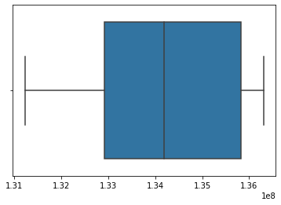

```python
sns.boxplot(imputation_err)
plt.show()
```

## Imputacja dla dówch kolumn

Powtórzmy teraz powyższy eksperyment, teraz jednak usuńmy dane z dwóch kolumn oraz poddajmy je imputancji.

```python
import random
from random import uniform
imputation_err_2 = [0] * 10

for i in range(10):
    df_copy = df[['price','it_seller_rating','it_quantity']]
    df_copy.loc[df_fill.sample(frac=0.1, random_state=random.randint(0, 80)).index, "it_quantity"] = None
    df_copy.loc[df_fill.sample(frac=0.1, random_state=random.randint(0, 80)).index, "it_seller_rating"] = None

    imp = IterativeImputer(max_iter=10, random_state=i)
    df_copy = pd.DataFrame(imp.fit_transform(df_copy))
    df_copy = df_copy.rename(columns={0: "price", 1: "it_seller_rating",2:"it_quantity"})
    imputation_err_2[i] = mean_squared_error(df['it_seller_rating'], df_copy['it_seller_rating'])
imputation_err_2
```

```
[134252556.01898506,
 134501119.1589959,
 133818204.88091907,
 133080314.60524961,
 138444002.5037198,
 136386535.95764408,
 139413191.11284354,
 134359233.11813948,
 131683627.66020265,
 133861239.75528444]
```

```python
st.stdev(imputation_err_2)
st.mean(imputation_err_2)
print("Odchylenie standardowe dla próbki wynosi",st.stdev(imputation_err_2), "a jej średnia", st.mean(imputation_err_2))
```

```
Odchylenie standardowe dla próbki wynosi 2400253.7111580563 a jej średnia 134980002.47719836
```

```python
sns.boxplot(imputation_err_2)
plt.show()
```

[output not shown]

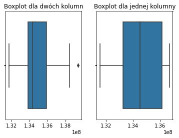

```python
plt.subplot(1, 2, 1)
sns.boxplot(imputation_err_2)
plt.title('Boxplot dla dwóch kolumn')
plt.subplot(1, 2, 2)
sns.boxplot(imputation_err)
plt.title('Boxplot dla jednej kolumny')
plt.show()
```

Jak widzimy zastosowanie imputancji dla dwóch kolumn zwiększyło ilość outlierów oraz rozszerzyło dystrubucje wyników, lecz nie o znaczną wartość, choć średnia wyników została praktycznie zachowana. Dla 10 prób niestety nie można stwierdzić poważniejszych wyników, gdyż nie jest to wystarczająca ilość danych. Wyniki "na logikę" zgadzają się z przypuszczeniami, iż dokonanie zamiany wartości dla większej ilości kolumn spowoduje większy błąd.